# Pipelining HIV+ Country-wide Meta-analysis of Sub-Saharan Africa

### Source file:

- s3://dhs-hivdata/univariateResults.0923.tgz

### Notes from meeting, 10/30

- latent variable analysis - farmworker or fisherman, asked about it different ways; look at the varlabel string

[output not shown]

```r
## meta-analysis code
meta_for_one <- function(estimates, ses, ...) {
  ## Dersimonian-Laird RF
  mod <- rma.uni(yi=estimates, sei=ses, method = 'DL', ...)
  return(mod)
}
```

## Raw Number of Replicated Associations

- replicated in 2 independent datasets (FDR < 0.05 and p < 0.05)

```r
nrow(summary_statistics)
```

```
## [1] 71778
```

```r
hiv_train$data_type <- 'train'
hiv_test$data_type <- 'test'
trainTest <- rbind(unique(hiv_train), unique(hiv_test))

numInBothTrainAndTest <- trainTest %>% group_by(country, survey, gender, var) %>% summarize(n=n()) %>% filter(n == 2) %>% ungroup() %>% select(-n) %>% group_by(country, survey, gender) %>% summarize(total=n())

numReplicated <- summary_statistics %>% group_by(country, survey, gender) %>% summarize(n=n())

yield <- left_join(numInBothTrainAndTest, numReplicated) %>% mutate(pct = n/total)
DT::datatable(yield)
```

|  | country | survey | gender | total | n | pct |
| --- | --- | --- | --- | --- | --- | --- |
| 1 | Angola | Standard_DHS_2015-16 | f | 4149 | 728 | 0.175463967221017 |
| 2 | Angola | Standard_DHS_2015-16 | m | 2917 | 737 | 0.252656839218375 |
| 3 | Burkina_Faso | Standard_DHS_2003 | f | 4122 | 864 | 0.209606986899563 |
| 4 | Burkina_Faso | Standard_DHS_2003 | m | 2976 | 820 | 0.275537634408602 |
| 5 | Burkina_Faso | Standard_DHS_2010 | f | 3984 | 1439 | 0.361194779116466 |
| 6 | Burkina_Faso | Standard_DHS_2010 | m | 2879 | 974 | 0.338311913858979 |
| 7 | Burundi | Standard_DHS_2010 | f | 3653 | 1087 | 0.297563646318095 |
| 8 | Burundi | Standard_DHS_2010 | m | 2288 | 694 | 0.303321678321678 |
| 9 | Cameroon | Standard_DHS_2004 | f | 3927 | 682 | 0.173669467787115 |
| 10 | Cameroon | Standard_DHS_2004 | m | 2576 | 440 | 0.170807453416149 |

[output cut: 88 more lines]

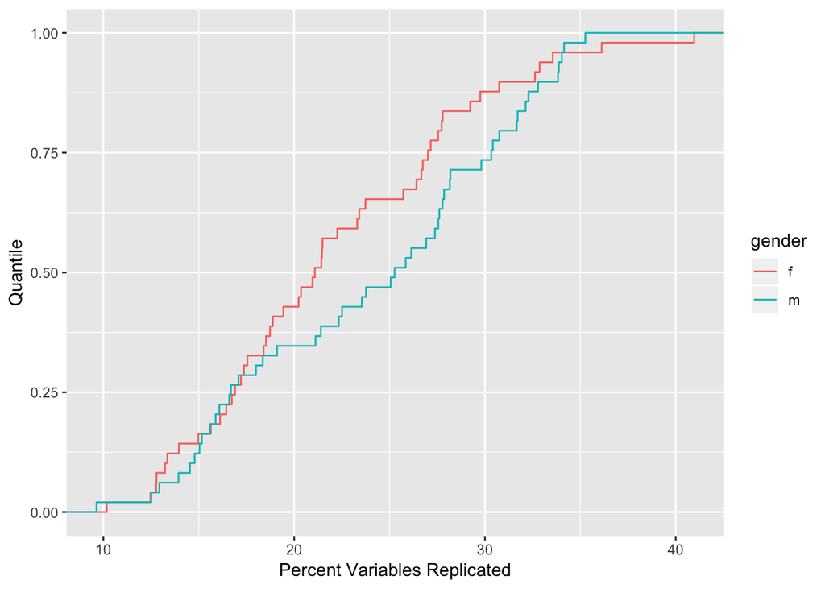

```r
p <- ggplot(yield, aes(pct*100, color=gender))
p <- p + stat_ecdf()
p <- p + xlab('Percent Variables Replicated') + ylab('Quantile')
p
```

## How many times each variable was found

```r
varDesc <- unique(summary_statistics[, c('var', 'varlabel')]) %>% group_by(var) %>% filter(row_number() == 1)
metaCharacteristics <- summary_statistics %>% group_by(gender, var) %>% summarise(n_surveys=n(), n_countries=length(unique(country))) %>% merge(., varDesc)
DT::datatable(metaCharacteristics[order(metaCharacteristics$n_surveys, decreasing=T),], rownames = F)
```

| var | gender | n_surveys | n_countries | varlabel |
| --- | --- | --- | --- | --- |
| v501_3 | f | 38 | 23 | current marital status |
| v502_2 | f | 36 | 22 | currently/formerly/never in union |
| v535_0 | f | 36 | 22 | ever been married or in union |
| v536_0 | f | 36 | 23 | recent sexual activity |
| v012 | f | 33 | 19 | respondent's current age |
| v013_1 | f | 33 | 19 | age in 5-year groups |
| v013_1 | m | 32 | 19 | age in 5-year groups |
| v150_1 | m | 32 | 17 | relationship to household head |
| v150_1 | f | 31 | 18 | relationship to household head |
| v502_0 | m | 31 | 17 | currently/formerly/never marr. |

[output cut: 24902 more lines]

### within country

```r
surveyChars <- strsplit(summary_statistics$survey, "\\_")
summary_statistics$year <- unlist(lapply(surveyChars, function(x) { x[3] }))

## within a country, count how many surveys for a variable
numVariablesPerCountry <- summary_statistics %>% group_by(country, var, gender) %>% summarize(num_surveys=n())
meta_analysis_country <- summary_statistics %>% group_by(country, var, gender) %>% do(meta=meta_for_one(.$Estimate, .$SE, slab=sprintf('%s-%s-%s', .$country, .$year, .$gender)))
meta_analysis_country <- left_join(numVariablesPerCountry, meta_analysis_country)
```

### within entire var

```r
numVariablesPerContinent <- summary_statistics %>% group_by(var, gender) %>% summarize(num_surveys=n())
meta_analysis_continent <- summary_statistics %>% group_by(var, gender) %>% do(meta=meta_for_one(.$Estimate, .$SE, slab=sprintf('%s-%s-%s', .$country, .$year, .$gender)))
meta_analysis_continent <- left_join(meta_analysis_continent, numVariablesPerContinent)
```

## save the work

```r
save(yield, meta_analysis_country, meta_analysis_continent, summary_statistics, varDesc, metaCharacteristics, file='meta_hiv_110518.Rdata')
```